# Teste de hipóteses para uma amostra

Rumenick Pereira da Silva

26 de março de 2019

## Conjunto de dados

```r
set.seed(12232)
dados <- data.frame(id = 1:30,
                    ordem = sample(1:30),
                    alpha = rnorm(n = 30, mean = 15, sd = 6))
dados
```

```
##    id ordem     alpha
## 1   1    11 17.228983
## 2   2    16 10.946777
## 3   3    24 22.017382
## 4   4    18 11.191133
## 5   5    21  6.757707
## 6   6    25 15.729446
## 7   7    13  3.697234
## 8   8    26 11.496106
## 9   9    14 13.017550
## 10 10     8 11.873145
## 11 11     7 12.256707
## 12 12     1  7.517931
## 13 13    22 17.677844
## 14 14    23 19.768407
```

[output cut: 16 more lines]

## Exploração inicial

### Análise descritiva

```r
# Medidas resumo da amostra:
summary(dados$alpha)
```

```
##    Min. 1st Qu.  Median    Mean 3rd Qu.    Max.
##   3.424  11.008  14.222  14.536  19.443  26.071
```

```r
cat("Desvio padrão amostral:", sd(dados$alpha))
```

```
## Desvio padrão amostral: 6.111592
```

```r
cat("Coeficiente de variação amostral:", sd(dados$alpha) / mean(dados$alpha) * 100)
```

```
## Coeficiente de variação amostral: 42.04472
```

### Checando a distribuição dos dados visualmente

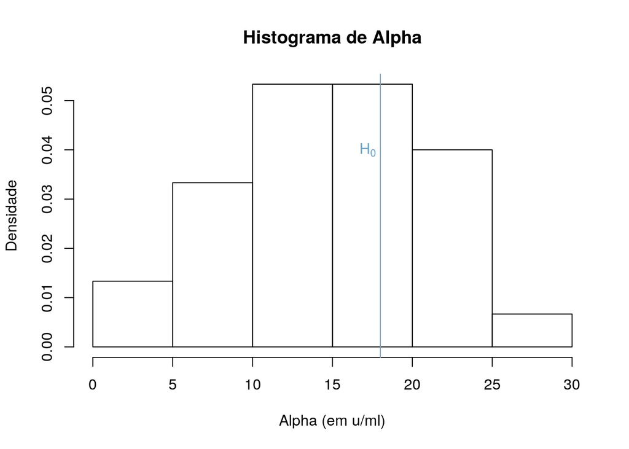

```r
hist(x = dados$alpha,
     probability = TRUE,
     ylab = "Densidade",
     xlab = "Alpha (em u/ml)",
     main = "Histograma de Alpha")
abline(v = 18, col = "#6aa4c8")
text(x = 18 - 0.8, y = 0.04, labels = expression(H[0]), col = "#6aa4c8")
```

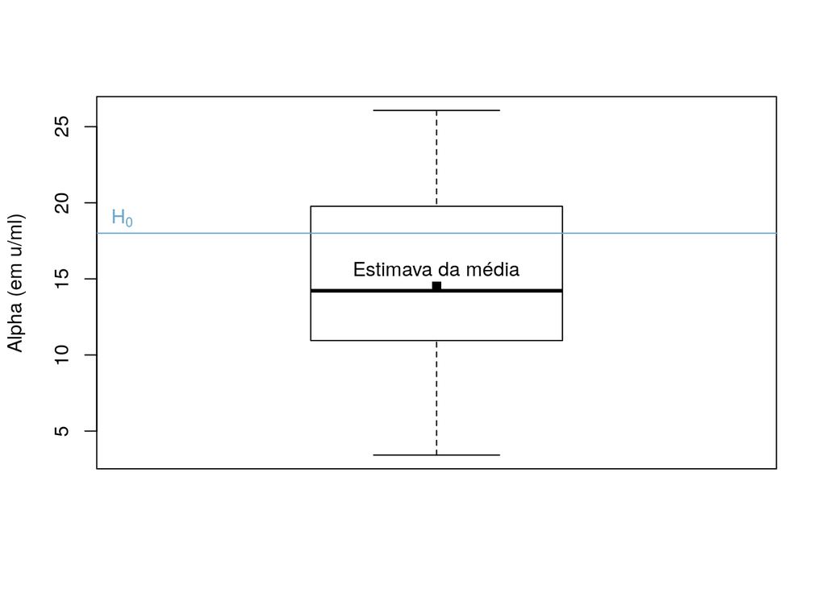

```r
boxplot(x = dados$alpha, ylab = "Alpha (em u/ml)")
abline(h = 18, col = "#6aa4c8")
text(x = .5, y = 19, labels = expression(H[0]), col = "#6aa4c8")
points(x = 1, y = mean(dados$alpha), pch = 15)
text(x = 1, y = mean(dados$alpha) + 1.1, labels = "Estimava da média")
```

### Checando a distribuição dos dados usando testes de hipóteses

$H_0$ : as medidas de Alpha realizada na amostra são provenientes de uma distribuição normal;

$H_a$: as medidas de Alpha realizada na amostra **não** são provenientes de uma distribuição normal;

#### Teste de normalidade de Shapiro-Wilk

```r
shapiro.test(x = dados$alpha)
```

```
##
##  Shapiro-Wilk normality test
##
## data:  dados$alpha
## W = 0.9687, p-value = 0.5043
```

#### Teste de normalidade usando o teste de Kolmogorov-Smirnov

```r
ks.test(x = dados$alpha, y = "pnorm", mean = mean(dados$alpha), sd = 6)
```

```
##
##  One-sample Kolmogorov-Smirnov test
##
## data:  dados$alpha
## D = 0.10656, p-value = 0.8497
## alternative hypothesis: two-sided
```

### Testes de hipóteses para média de uma população normal com variância conhecida

```r
# install.packages("TeachingDemos")
library(TeachingDemos) # Para realizar o teste Z

# Realizando o teste:
z.test(x = dados$alpha, mu = 18, stdev = 6, alternative = "less")
```

```
##
##  One Sample z-test
##
## data:  dados$alpha
## z = -3.1622, n = 30.0000, Std. Dev. = 6.0000, Std. Dev. of the
## sample mean = 1.0954, p-value = 0.0007828
## alternative hypothesis: true mean is less than 18
## 95 percent confidence interval:
##      -Inf 16.33778
## sample estimates:
## mean of dados$alpha
##            14.53593
```

### Teste de hipóteses sobre a variância de uma população normal

Cassio gostaria de confirmar se existe evidências que a variância de Alpha encontrada na etapa de planejamento (36) está coerente a luz da amostra observada. Logo ele realizou o seguinte teste:

$H_0$: $\sigma^2 = 36$ ou $\sigma = 6$

$H_1$: $\sigma^2 \neq 36$ ou $\sigma \neq 6$

```r
# install.packages("TeachingDemos")
library(TeachingDemos) # Para realizar o teste Z

# Realizando o teste:
sigma.test(x = dados$alpha, sigma = 6, alternative = "two.sided")
```

```
##
##  One sample Chi-squared test for variance
##
## data:  dados$alpha
## X-squared = 30.089, df = 29, p-value = 0.8192
## alternative hypothesis: true variance is not equal to 36
## 95 percent confidence interval:
##  23.69075 67.50111
## sample estimates:
## var of dados$alpha
##           37.35156
```

### Teste de hipóteses sobre a média de uma população normal com variância desconhecida

```r
library(stats) # Para realizar o teste T

# Realizando o teste:
t.test(x = dados$alpha, mu = 18, alternative = "less")
```

```
##
##  One Sample t-test
##
## data:  dados$alpha
## t = -3.1045, df = 29, p-value = 0.002115
## alternative hypothesis: true mean is less than 18
## 95 percent confidence interval:
##      -Inf 16.43185
## sample estimates:
## mean of x
##  14.53593
```

### Teste de hipóteses sobre a proporção de uma população

Suponha que por algum motivo Cassio não esta preocupado com os valores exato da medida Alpha, porém ele deseja saber se a amostra confirma a hipótese que após tratamento a proporção de pessoas com valor de Alpha menor que 18 é maior que 50% na população. Para Cassio, se 50% ou mais elemetos reduziu a carga de Alpha, isso atestaria a eficácia do seu tratamento.

$H_0$: $p = 0,5$

$H_a$: $p > 0,5$

```r
dados <-
  dados %>%
  mutate(alpha_menor_18 = factor(ifelse(alpha < 18, "Sim", "Não"), levels = c("Sim", "Não")))
dados
```

```
##    id ordem     alpha alpha_menor_18
## 1   1    11 17.228983            Sim
## 2   2    16 10.946777            Sim
## 3   3    24 22.017382            Não
## 4   4    18 11.191133            Sim
## 5   5    21  6.757707            Sim
## 6   6    25 15.729446            Sim
## 7   7    13  3.697234            Sim
## 8   8    26 11.496106            Sim
## 9   9    14 13.017550            Sim
## 10 10     8 11.873145            Sim
## 11 11     7 12.256707            Sim
## 12 12     1  7.517931            Sim
## 13 13    22 17.677844            Sim
## 14 14    23 19.768407            Não
```

[output cut: 16 more lines]

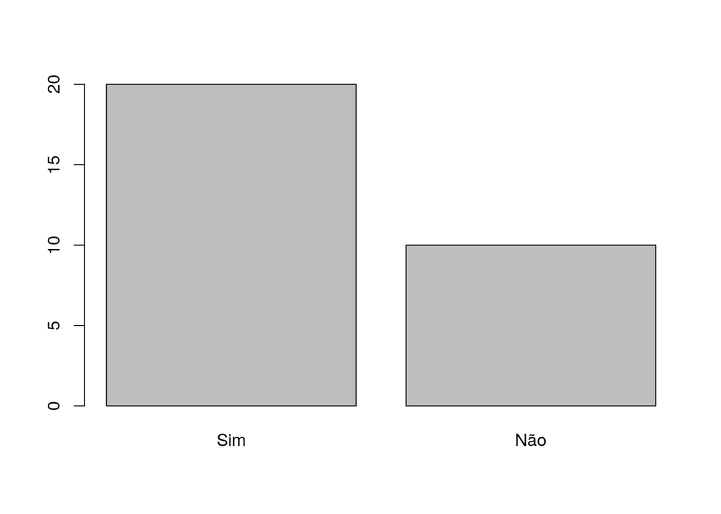

```r
tab <- table(dados$alpha_menor_18)
barplot(tab)
```

```r
prop.table(tab)
```

```
##
##       Sim       Não
## 0.6666667 0.3333333
```

```r
prop.test(x = table(dados$alpha_menor_18), p = 0.5, alternative = "greater")
```

```
##
##  1-sample proportions test with continuity correction
##
## data:  table(dados$alpha_menor_18), null probability 0.5
## X-squared = 2.7, df = 1, p-value = 0.05017
## alternative hypothesis: true p is greater than 0.5
## 95 percent confidence interval:
##  0.4998461 1.0000000
## sample estimates:
##         p
## 0.6666667
```

## Alternativas para a quebra de pressuposto de normalidade dos dados

### Teste sobre o parâmetro de locação (mediana) de uma população

```r
wilcox.test(x = dados$alpha, mu = 18, alternative = "less")
```

```
##
##  Wilcoxon signed rank test
##
## data:  dados$alpha
## V = 105, p-value = 0.003806
## alternative hypothesis: true location is less than 18
```